# 第18回 事前学習

作者

J22069 野倉悠正

公開

2026年11月5日

> このドキュメントは、[GitHub Pages](https://yumachin2003.github.io/docs/zemi26/18)からも閲覧可能である。

# 1 はじめに

前回までは信州おまつりナビをネイティブ化する作業を行っていたが、10月20日の関先生とのヒアリングにて、「おまつりナビではなく坂城町講座で用いた『さかき思い出マップ』をネイティブアプリ化した方がいいのではないか」というご指摘をいただいた。本来ネイティブアプリ化の動機は**オフライン機能の強化**である。おまつりナビには投稿機能がないのと、時系列的に「さかき思い出マップ」の方が後にできたシステムであるため、**成果報告会での説得力の担保**、及び**ストーリーの透明化を図る**ためにも、今回から「さかき思い出マップ」のネイティブアプリ化を進めていくことにした。

# 2 サーバーからのデータ取得

Webアプリでは、サーバーのデータはAPIリンクを介してJSON形式で取得する形だった。データの取得方法を理解するため、まずは既存の「[さかき思い出マップ](https://www.sekilab.org/sakaki-map/)」の、システム構成の確認を行っていく。

## 2.1 既存システムの構成の確認

### 2.1.1 バックエンドのAPIリンクの構成

バックエンドのファイルを見直し、APIのリンクをまとめていく。エンドポイントは全て [`app.py`](https://github.com/yumachin2003/sakaki-map/blob/main/backend/app.py) で定義されていたので、そのファイルを確認すると、以下のエンドポイントが定義されていた。

#### 思い出のデータ関係

| エンドポイント | メソッド | 説明 |
| --- | --- | --- |
| `/api/memories` | GET, POST | 保存されている思い出データの取得・保存 |
| `/api/update-path` | POST | 画像パスの更新（Viteプラグインからの送信用） |

#### アカウント関係

| エンドポイント | メソッド | 説明 |
| --- | --- | --- |
| `/api/login` | POST | ログイン処理 |
| `/api/accounts` | GET, POST | 保存されているアカウントデータの取得・作成・更新 |

**ヒントHTTPリクエストとメソッド**

**HTTPリクエスト**とは、Webブラウザやアプリなどのクライアントが、Webサーバーに対して「データを取得したい」「データを新しく登録したい」といった処理を要求するための通信のこと。

その要求の目的を表すのが**HTTPメソッド**であり、主に以下の種類が使われる。

- **GET**: サーバーから情報やリソースを取得する（最もよく使われる）
- **POST**: サーバーに新しいデータを送信・作成する
- **PUT / PATCH**: サーバー上のデータを更新・修正する
- **DELETE**: サーバー上のデータを削除する

このエンドポイントを使い、`https://www.sekilab.org/sakaki-map/api/<endpoint>`のようにリクエストを送ることでデータを取得できる。

例えば、思い出データは以下のリンクから取得できる。

> https://www.sekilab.org/sakaki-map/api/memories

リンクを開くと、以下のようなJSONデータが出てくる。

[figure not shown]

文字化けしているように見えるのは、FlaskがJSONを返すときに日本語（ASCII以外の文字）をUnicodeエスケープ（`\uXXXX`）に変換してしまうからである。Chromeの場合、左上の「**プリティプリント**」にチェックを入れると、以下の画像のように正しく表示できるようになる。

▼クリックで表示

[figure not shown]

### 2.1.2 データベースの構成

同じくデータベースの構成も確認した。データベースのモデルはAPIと同じく [`app.py`](https://github.com/yumachin2003/sakaki-map/blob/main/backend/app.py) で定義されている。

データベースには、主に以下の3つのテーブルが定義されている。

1. **`accounts`**：生徒のアカウント情報とUI設定（ピンの色やフォントなど）を管理
2. **`memories`**：思い出のデータを管理
3. **`memory_images`**：思い出に紐づく画像のパスを管理

#### `accounts`テーブル（Accountモデル）

生徒のアカウント情報およびUIの表示設定（ピンの色やフォントサイズなど）を管理するテーブル。

| カラム名 | 型 | 制約 | 説明 |
| --- | --- | --- | --- |
| `id` | Integer | PRIMARY KEY, AUTOINCREMENT | アカウントID |
| `username` | String(50) | UNIQUE, NOT NULL | ユーザー名 |
| `password_hash` | String(200) | - | ハッシュ化されたパスワード |
| `pinColor` | String(50) | NOT NULL, DEFAULT: `'red'` | 地図上のピンの色 |
| `textSize` | Numeric | NOT NULL, DEFAULT: `15` | テキストサイズ |
| `fontFamily` | String(100) | NOT NULL, DEFAULT: `'sans-serif'` | フォントファミリー |

#### `memories`テーブル（Memoryモデル）

地図上に表示される思い出の、ピンの座標やエピソードを管理するテーブル。

| カラム名 | 型 | 制約 | 説明 |
| --- | --- | --- | --- |
| `id` | Integer | PRIMARY KEY | 思い出ID |
| `name` | String(100) | NOT NULL | 思い出のスポット名・名称 |
| `latitude` | Float | NOT NULL | 緯度 |
| `longitude` | Float | NOT NULL | 経度 |
| `detail` | String(500) | - | 思い出の詳細・エピソード |
| `account_id` | Integer | FOREIGN KEY (`accounts.id`) | 投稿したユーザーのアカウントID |

#### `memory_images`テーブル（MemoryImageモデル）

各思い出に紐づく画像パスを管理するテーブル。1つの思い出に対して複数の画像を紐づけることができる。

| カラム名 | 型 | 制約 | 説明 |
| --- | --- | --- | --- |
| `id` | Integer | PRIMARY KEY, AUTOINCREMENT | 画像ID |
| `memories_id` | Integer | FOREIGN KEY (`memories.id`), NOT NULL | 紐づく思い出のID |
| `imageUrl` | Text | NOT NULL | 画像のファイルパスまたはURL |
| `account_id` | Integer | FOREIGN KEY (`accounts.id`) | 画像を追加したユーザーのアカウントID |

## 2.2 思い出データをマップビューにプロットするロジックの作成

サーバーからデータを取得し、座標を`CLLocationCoordinate2D`[^1]の形式に変換し、最終的に`[Memory]`配列としてまとめたデータを、マップビューにプロットするロジックを作成する。

### 2.2.1 サーバーからデータを取得する（`MemoryService`）

まずはAPIリンクを叩き、サーバーからJSONデータを取得するロジックを作成する。`ContentView.swift`とは別に新しく`APIService.swift`というファイルを作成し、`MemoryService`という列挙型を定義する。

**ヒントSwiftの「名前付き型」**

**名前付き型**とは、Swiftにおいて開発者が独自に名前をつけて定義できるデータの型のこと。

**（表）名前付き型の種類**

| 特徴 | 列挙型 (`enum`) | 構造体 (`struct`) | クラス (`class`) |
| --- | --- | --- | --- |
| **主な用途** | 限定された選択肢の管理 | 複数のデータのパッケージ化 | 共通データの共有・継承 |
| **データの持ち方** | どれか1つのケースのみ | 複数のプロパティをすべて保持 | 複数のプロパティをすべて保持 |
| **型システム** | 値型（コピーされる） | 値型（コピーされる） | 参照型（共有される） |
| **初期値の保持** | 不可（ストアドプロパティはNG） | 可能 | 可能 |
| **継承** | 不可 | 不可 | 可能（親子関係を作れる） |

わかりやすくいうと、

- 列挙型（`enum`）は、「道路の信号機（青・黄・赤）」である。あらかじめ決まった選択肢の中から、**いま、どの色のランプがついているか（どれか1つの状態）**だけを切り替えて示すために使う。
- 構造体（`struct`）は、「お店のランチセット（ハンバーグ＋ライス＋サラダ）」である。関連する複数のデータを**1つのパッケージ**にまとめ、使う人ごとに**丸ごと新しくコピー**して配る。自分が自分のハンバーグを一口食べても、**隣の人のハンバーグは減らない（データが独立している）**。
- クラス（`class`）は、みんなで書き込む「教室のホワイトボード」である。データ（実体）は部屋に1つしかなく、それを**全員で共有して**使う。誰かがホワイトボードの文字を書き換えると、**他の全員から見ても内容が変化する（データが全員に連動する）**。

といった感じだろう。

Swiftの「名前付き型」の概念

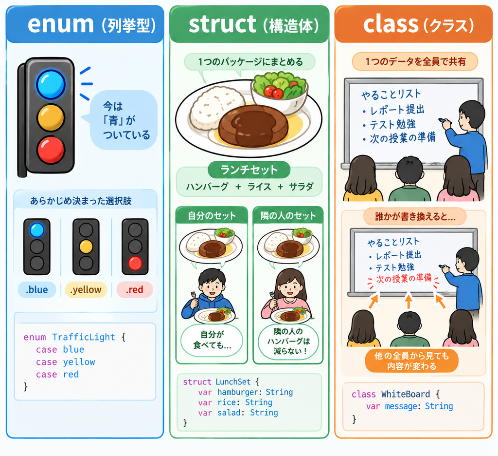

```
APIService.swift
```

```
import Foundation
import MapKit

struct Memory: Decodable, Identifiable {
    let id: Int
    let name: String
    let latitude: Double
    let longitude: Double
    var coordinate: CLLocationCoordinate2D {
        CLLocationCoordinate2D(latitude: latitude, longitude: longitude)
    }
}

enum MemoryService {
    private static let endpoint = "https://www.sekilab.org/sakaki-map/api/memories"
    static func fetchMemories() async throws -> [Memory] {
        guard let url = URL(string: endpoint) else { return [] }
        let (data, _) = try await URLSession.shared.data(from: url)
        return try JSONDecoder().decode([Memory].self, from: data)
    }
}
```

**1**

`Foundation`という、`URL`や`URLSession`、`JSONDecoder`など、通信やデータ処理に必要な基本機能を提供するフレームワークを読み込む。

**2**

サーバーから取得する思い出データをSwift内で扱うための構造体。`Decodable`（JSONからデータを変換可能にする）と`Identifiable`（`id`でデータを一意に識別可能にする）に準拠し、緯度・経度からマップ用の座標（`CLLocationCoordinate2D`）を計算して返すプロパティを持たせている。

**3**

`endpoint`から生データを取得し、`Memory`オブジェクトの配列に変換する列挙型。

**4**

APIのURL文字列。外部から勝手に書き換えられないよう`private static`に設定している。

**5**

`async`（時間のかかる通信をアプリをフリーズさせずに待機できる非同期処理）と、`throws`（通信障害などのエラー時に呼び出し元へエラーを通知できる仕組み）を持つ`fetchMemories()`関数。成功すると`Memory`オブジェクトの配列（`[Memory]`）を返す。

**6**

文字列から`URL`オブジェクトを作成する。URLの形式が無効な場合は安全に空の配列`[]`を返して終了する（`guard let`構文）。

**7**

インターネット経由で`url`にアクセスし、サーバーから生データ（`data`）を取得する。通信完了まで処理を一時停止（`await`）し、失敗時はエラーを投げる（`try`）。

**8**

サーバーから送られてきたJSON形式の生データを、`JSONDecoder()`という関数を使ってSwiftで扱いやすい `[Memory]` 型（構造体の配列）に自動で変換して返す。`.self`を付加することにより、「値」ではなく「`[Memory]`という型そのもの」をデコード対象として引数に渡している。

### 2.2.2 マップへのピンの表示（`MemoryMapView`）

サーバーからデータを取得して`[Memory]`配列に変換した思い出の座標を使って、マップビューにピンを表示するロジックを実装する。並びに、`body`内にあったマップビューを`MemoryMapView`という構造体にして管理しやすくした。

```
ContentView.swift
```

```
import SwiftUI
import MapKit

extension CLLocationCoordinate2D {
    static let nagano_univ = CLLocationCoordinate2D(
        latitude: 36.36915007647547,
        longitude: 138.22364515597747
    )
}

/// === 地図ビューの定義 ===
struct MemoryMapView: View {
    @State private var memories: [Memory] = []
    @StateObject private var locationManager = LocationManager()

    var body: some View {
        Map(
            initialPosition: .camera(
                MapCamera(centerCoordinate: .nagano_univ, distance: 60000)
            )
        ) {
            ForEach(memories) { memory in
                Marker(memory.name, coordinate: memory.coordinate)
            }
            UserAnnotation()
        }
            .mapControls {
                MapUserLocationButton()
                MapCompass()
            }
            .task {
                do {
                    memories = try await MemoryService.fetchMemories()
                } catch {
                    print("データの取得に失敗しました: \(error)")
                }
            }
    }
}

/// === アプリのメイン画面 ===
struct ContentView: View {
    var body: some View {
        MemoryMapView()
    }
}


#Preview {
    ContentView()
}
```

**1**

`CLLocationCoordinate2D`型を拡張（`extension`）し、初期表示に使う長野大学の座標を定数`nagano_univ`として定義している（[第17回](https://yumachin2003.github.io/docs/zemi26/17#:~:text=extensionは、既存,している%E3%80%82)）。

**2**

マップ表示とピン描画の画面部品をまとめた**構造体（カスタムビュー）**。

**3**

サーバーから取得した思い出一覧を保持する**状態変数（`@State`）**。この変数の値が更新されると、**SwiftUIが自動で画面を再描画**する。

**4**

前回追加した[`LocationManager`](https://yumachin2003.github.io/docs/zemi26/17#locationmanagerクラスの定義)のインスタンス（[第17回](https://yumachin2003.github.io/docs/zemi26/17#マップビューでの使用)）。前回は`ContentView`に置いていたが、マップビューを`MemoryMapView`に切り出したのに合わせてこちらへ移動した。`@StateObject`で保持することで、画面の再描画時にもインスタンスが破棄されず、位置情報の利用許可リクエストや現在地の追跡が継続される。

**5**

**6**

地図が表示された直後の**初期カメラ位置**（第17回）。前回は50万メートル（500km）になっていたが、さかき思い出マップになり、画面に坂城町内が収まれば良いので**6万メートル（60km）に変更**してある。

**7**

**`memories`配列内のデータを1件ずつ取り出し、ピン（`Marker`）として地図上に配置**するループ処理。

**8**

ユーザーの現在地を示す青い円（現在地マーカー）を地図上に表示する（[第17回](https://yumachin2003.github.io/docs/zemi26/17#:~:text=地図上に現在地を表す青い円（現在地マーカー）を表示するビュー%E3%80%82これ一行を記述するだけで、取得された端末の現在位置に自動で標準の現在地アイコンがプロットされ、移動に合わせて追従する%E3%80%82)）。

**9**

**地図操作コントロール**を画面に追加する。前回は現在地ボタンのみだったが、**コンパス（`MapCompass()`）**も新たに追加してある。

**10**

地図ビューが表示されたタイミングで**非同期処理（`async`）を実行するモディファイア**。先ほど`APIService.swift`で実装した`MemoryService.fetchMemories()`を呼び出してデータを取得し、`memories`に代入して画面を更新する。失敗時はエラー内容をコンソールに出力する。

**11**

`MemoryMapView`を呼び出して表示。

## 2.3 証明書検証の無効化

この実装で実行したところ、マップにピンが表示されずコンソールに以下のようなエラーが出ていた。

```
コンソールのエラー内容
```

```
Connection 1: default TLS Trust evaluation failed(-9814)
Task <163909F9-...>.<1> HTTP load failed, 0/0 bytes (error code: -1202 [3:-9814])
Task <163909F9-...>.<1> finished with error [-1202]
  Error Domain=NSURLErrorDomain Code=-1202
  "このサーバの証明書は無効です。“www.sekilab.org”に偽装したサーバに接続している可能性があり、機密情報が漏えいするおそれがあります。"
  UserInfo={
    _kCFStreamErrorDomainKey=3,
    _kCFStreamErrorCodeKey=-9814,
    NSErrorPeerCertificateChainKey=(
      "<cert s: www.sekilab.org i: YE2>",
      "<cert s: YE2 i: Root YE>",
      "<cert s: Root YE i: ISRG Root X2>",
      "<cert s: ISRG Root X2 i: ISRG Root X1>"
    ),
    NSErrorFailingURLKey=https://www.sekilab.org/sakaki-map/api/memories,
    ...中略...
  }
```

Claudeにエラーを解読させたところ、`-9814`（`errSSLCertExpired`）は「**証明書が失効している**」というエラーコードであり、それにより`-1202`（`NSURLErrorServerCertificateUntrusted`）の「**サーバ証明書が信用できない**」というエラーコードが出ている状況であった。

### 2.3.1 現在のゼミサーバーの証明書の状況

ゼミサーバーの証明書は、[2025年度](https://yumachin2003.github.io/docs/zemi25/tech-repo_25th#:~:text=適用される%E3%80%82-,6.2%20自己署名証明書の生成,-パスワードやメールアドレス)に自己署名証明書をインストールし、[2026年度の第2・3回](https://yumachin2003.github.io/docs/zemi26/02_03)でLet’s Encryptの正規の証明書に更新していた。しかし、この証明書はすでに**90日の有効期限を過ぎ、期限切れ**となっていた。現在は複数のサブドメインに対応するため、**ワイルドカード証明書をDNS-01チャレンジで手動取得**している。`sekilab.org`のDNSはさくらインターネットのドメイン管理であり、TXTレコードを更新するAPIがないため、90日ごとの自動更新を実現するには**acme-dns方式**[^2]を用いる必要があり、現在はacme-dnsの導入による証明書取得の自動化の作業で止まっている。

### 2.3.2 証明書検証のスキップ（`InsecureURLSession`）

ひとまず今回はネイティブ化の完成を第一優先とするため、仮の措置として**証明書の検証をスキップ**するように実装する。`APIService.swift`を以下のように書き換える。

```
APIService.swift
```

```
/// 思い出データの取得を担当するサービス
enum MemoryService {
    private static let endpoint = "https://www.sekilab.org/sakaki-map/api/memories"

    /// APIから思い出データを取得して返す
    static func fetchMemories() async throws -> [Memory] {
        guard let url = URL(string: endpoint) else { return [] }
        let (data, _) = try await InsecureURLSession.shared.data(from: url)
        return try JSONDecoder().decode([Memory].self, from: data)
    }
}

// ============================================================================
// ⚠️ 一時回避コード：サーバーの証明書が期限切れのための暫定対応
// ----------------------------------------------------------------------------
// サーバー側の証明書が更新されたら、このブロックごと丸ごと削除し、
// fetchMemories() 内の `InsecureURLSession.shared` を `URLSession.shared` に戻す。
// （本番運用では証明書検証を無効化したままにしないこと）
// ----------------------------------------------------------------------------
enum InsecureURLSession {
    static let shared: URLSession = {
        URLSession(
            configuration: .default,
            delegate: InsecureSessionDelegate(),
            delegateQueue: nil
        )
    }()
}

private final class InsecureSessionDelegate: NSObject, URLSessionDelegate {
    func urlSession(
        _ session: URLSession,
        didReceive challenge: URLAuthenticationChallenge,
        completionHandler: @escaping (URLSession.AuthChallengeDisposition, URLCredential?) -> Void
    ) {
        // サーバー信頼評価のチャレンジを無条件に受け入れる（証明書検証を無効化）
        guard challenge.protectionSpace.authenticationMethod == NSURLAuthenticationMethodServerTrust,
              let serverTrust = challenge.protectionSpace.serverTrust else {
            completionHandler(.performDefaultHandling, nil)
            return
        }
        completionHandler(.useCredential, URLCredential(trust: serverTrust))
    }
}
// ----------------------------------------------------------------------------
// ⚠️ 一時回避コードここまで
// ============================================================================
```

**1**

標準の`URLSession.shared`の代わりに、下で独自に作成した「証明書チェックを無視する通信設定」を持つ`InsecureURLSession.shared`に変更した。

**2**

アプリ全体で使い回せるよう、証明書チェックをスキップする設定を組み込んだ特別な`URLSession`を1つだけ生成・管理する列挙型。

**3**

通信相手（サーバー）から「この証明書で接続しても安全ですか？」と確認（認証チャレンジ）された際に、「問題ないのでそのまま接続を許可する（`.useCredential`）」と無条件で応答する通信の代理人[^3]クラス。

変更前 (`URLSession.shared`)

[figure not shown]

変更後 (`InsecureURLSession.shared`)

[figure not shown]

この変更により、サーバーのデータが無事に取得され、ピンが表示されるようになった。

[figure not shown]

### 2.3.3 ATSの例外設定（`Info.plist`）

iOSには**ATS（App Transport Security）**[^4]という仕組みがあり、安全でないと判断した通信はアプリのコードより手前のOSの段階でブロックされてしまう。証明書の検証をアプリ側でスキップしても、ATSが期限切れの証明書を持つサーバーとの通信を拒否してしまうため、`Info.plist`に`sekilab.org`だけを対象とした例外設定を追加する。

```
Info.plist
```

```xml
<!-- ===== ⚠️ 一時回避：sekilab.org のTLS構成がATS要件を満たさないための暫定例外 ===== -->
<!-- サーバーのTLS/証明書が正常化したら、この NSAppTransportSecurity ブロックごと削除する -->
<key>NSAppTransportSecurity</key>
<dict>
    <key>NSExceptionDomains</key>
    <dict>
        <key>sekilab.org</key>
        <dict>
            <key>NSIncludesSubdomains</key>
            <true/>
            <key>NSExceptionAllowsInsecureHTTPLoads</key>
            <true/>
            <key>NSExceptionMinimumTLSVersion</key>
            <string>TLSv1.0</string>
            <key>NSExceptionRequiresForwardSecrecy</key>
            <false/>
        </dict>
    </dict>
</dict>
<!-- ===== ⚠️ 一時回避ここまで ===== -->
```

**1**

例外を適用するドメインを指定する。アプリ全体のATSを無効化する`NSAllowsArbitraryLoads`は使わず、`sekilab.org`だけに例外の範囲を絞っている。

**2**

`www.sekilab.org`などのサブドメインにも同じ例外を適用する。

**3**

安全でない通信の読み込みを許可する。HTTP通信だけでなく、**期限切れなどの無効な証明書を持つサーバーへのHTTPS通信**もこの設定で許可される。

**4**

要求するTLSの最低バージョンを、標準のTLS 1.2からTLS 1.0まで下げる。

**5**

前方秘匿性に対応した暗号方式の要求を外す。

前節の`InsecureURLSession`がアプリ側の証明書チェック、この設定がOS側の通信制限の回避であり、この2つを合わせることで、期限切れの証明書のままでもデータを取得できるようになった。

**重要**

ただし、どちらもセキュリティを下げる一時的な措置であるため、acme-dnsによる証明書の自動更新が完成したら、**必ず`Info.plist`のこのブロックと`InsecureURLSession`の両方を削除し、`URLSession.shared`に戻すこと**を忘れないようにする。

# 3 その他の変更

## 3.1 マップコントロールの配置変更

`.mapControls`で追加したコントロールは、MapKitの標準の配置である**画面右上**に表示される。iPhoneを片手で操作するときに親指が届きやすいよう、現在地ボタンとコンパスを**画面右下**に移動した。`MemoryMapView`を以下のように変更する。

```
ContentView.swift
```

```
struct MemoryMapView: View {
    @State private var memories: [Memory] = []
    @Namespace private var mapScope

    var body: some View {
        Map(
            initialPosition: .camera(
                MapCamera(centerCoordinate: .nagano_univ, distance: 60000)
            ),
            scope: mapScope
        ) {
            ForEach(memories) { memory in
                Marker(memory.name, coordinate: memory.coordinate)
            }
            UserAnnotation()
        }
        .overlay(alignment: .bottomTrailing) {
            VStack(spacing: 12) {
                MapUserLocationButton(scope: mapScope)
                    .buttonBorderShape(.circle)
                    .glassEffect(.regular.interactive(), in: Circle())
                MapCompass(scope: mapScope)
                    .buttonBorderShape(.circle)
                    .mapControlVisibility(.visible)
                    .glassEffect(.regular.interactive(), in: Circle())
            }
            .padding(.trailing, 16)
            .padding(.bottom, 32)
        }
        .mapControls {}
        .mapScope(mapScope)
        .task {
            // ... 中略 ...
        }
    }
}
```

**1**

マップとコントロールを結び付けるための**名前空間**。`@Namespace`で宣言した値を、マップとコントロールの両方に渡して使う。

**2**

このマップが`mapScope`に属することを指定する。

**3**

マップの上に重ねて表示するビュー（オーバーレイ）を、**右下（`.bottomTrailing`）**を基準に配置する。中の`VStack`で、現在地ボタンとコンパスを縦に並べている。

**4**

`.mapControls`の外に置いたコントロールは、そのままではどのマップを操作するのかがわからない。`scope: mapScope`を渡すことで、同じ`mapScope`に属するマップを操作できるようになる。

**5**

iOS 26で導入された**Liquid Glass**のデザインを円形で適用する。`.interactive()`を付けると、タップしたときにガラスが反応するアニメーションが付く。

**6**

コンパスは標準では地図を回転させたときにしか表示されないが、`.visible`を指定して常に表示するようにした。

**7**

標準の位置にコントロールが表示されないよう、空にしておく。

**8**

`Map`の外側にあるオーバーレイのコントロールからも`mapScope`を参照できるよう、スコープの範囲を設定する。

## 3.2 プロジェクトの整理

ネイティブ化の対象を「さかき思い出マップ」に変更したことに合わせて、以下の整理を行った。

- **プロジェクト名の変更**：プロジェクト名、フォルダ名、アプリの構造体名などを`shinshu-fesnav`から`sakaki-map-ios`に変更した。
- **名前の変更**：コード中の「お祭り（`Festival`）」の表記を「思い出（`Memory`）」に変更した（例：`FestivalService`→`MemoryService`、`FestivalMapView`→`MemoryMapView`）。
- **不要なコードの削除**：Xcodeでプロジェクトを作成したときに自動で生成された、SwiftDataのサンプルコード（`Item.swift`、`ModelContainer`の設定、`ContentView`内の追加・削除ボタンなど）を削除した。今回のアプリではデータをサーバーから取得するため、現時点では使用しない。
- **`.gitignore`の追加**：`.DS_Store`やXcodeのユーザー設定（`xcuserdata/`、`*.xcuserstate`）、ビルド成果物などをGitの追跡対象から除外した。特に`UserInterfaceState.xcuserstate`は、Xcodeでファイルを開いたりカーソルを動かしたりするだけで更新されるため、コミットのたびに不要な差分が出てしまっていた。

# 4 今回のまとめと次回やること

今回やったことは以下の通りである。

- ネイティブ化の対象を信州おまつりナビから「さかき思い出マップ」に変更
- 既存システムのAPIとデータベースの構成を確認
- サーバーから思い出データを取得し、マップにピンとして表示
- 期限切れの証明書への暫定対応として、証明書の検証のスキップとATSの例外設定を追加
- マップコントロールの配置変更
- プロジェクトの整理

証明書の検証のスキップとATSの例外設定はセキュリティを下げる措置であるため、acme-dnsによる証明書の自動更新が完成し次第、元の設定に戻したい。

なお、第19回の内容は今回と同時に報告するため、次回やることは省略し、第19回の資料にまとめて記載する。

[^1]: `CLLocationCoordinate2D`は、Swiftにおける2次元の位置座標を保持する構造体。詳しくは[第17回資料](https://yumachin2003.github.io/docs/zemi26/17#:~:text=CLLocationCoordinate2Dは、2,している%E3%80%82)を参照。
[^2]: **acme-dns方式**は、DNS-01チャレンジ専用の小さなDNSサーバー（acme-dns）に、`_acme-challenge`のレコードをCNAMEで委任する方式である。APIでTXTレコードを更新できるため、APIのないDNSでも自動更新が可能になる。ただし自前で運用する場合は、サーバーの53番ポートの開放と、メインのDNSへのNS委任の追加が必要であるため、少々セットアップが面倒である。
[^3]: これを**デリゲート**と呼ぶ。
[^4]: **ATS**は、iOS 9から導入された通信のセキュリティ機能である。アプリが行う通信に対して、HTTPSの使用、TLS 1.2以上、前方秘匿性（Forward Secrecy）に対応した暗号方式、有効な証明書などを要求し、条件を満たさない通信をOS側でブロックする。